# ODD Whole Data Analysis

Ahmet Turhal

## Introduction

- brand_name: Name of the brand
- auto_dom : Sales amount of domestic automobiles
- auto_imp : Sales amount of imported automobiles
- auto_total : Total sales amount of automobiles
- comm_dom : Sales amount of domestic commercial vehicles
- comm_imp : Sales amount of imported commercial vehicles
- comm_total : Total sales amount of commercial vehicles
- total_dom : Total sales of all domestic product vehicles
- total_imp : Total sales of all imported vehicles
- total_total: Total sales amount of all vehicles
- year : Year
- month : Month

In order to perform a healthy analysis, the dataset has been adjusted in three aspects: 1. Delete the invalid row that contains a disclaimer 2. Delete the rows brand_name = “TOPLAM:” 3. Change of “ASTON MARTIN” to “ASTON MARTIN” in order to merge the two different brand names for the same brand.

```r
library(tidyverse)
library(scales)
setwd('C:/Users/Turhal/Documents/Data Science/Big Data Essentials')
raw_data = read_rds("car_data_aggregate.rds")
raw_data = subset(raw_data,subset=brand_name != 'TOPLAM:' & !startsWith(brand_name, "ODD"))
raw_data$brand_name = str_replace(raw_data$brand_name, "MARTIN", "MARTIN")
#raw_data = raw_data %>% slice(-46)
raw_data[is.na(raw_data)] <- 0
```

```r
head(raw_data)
```

```
## # A tibble: 6 x 12
##   brand_name auto_dom auto_imp auto_total comm_dom comm_imp comm_total
##   <chr>         <dbl>    <dbl>      <dbl>    <dbl>    <dbl>      <dbl>
## 1 ALFA ROMEO        0       13         13        0        0          0
## 2 ASTON MAR~        0        2          2        0        0          0
## 3 AUDI              0      350        350        0        0          0
## 4 BENTLEY           0        0          0        0        0          0
## 5 BMW               0      158        158        0        0          0
## 6 CITROEN           0      134        134        0      197        197
## # ... with 5 more variables: total_dom <dbl>, total_imp <dbl>,
## #   total_total <dbl>, year <dbl>, month <dbl>
```

### Analysis I

Firstly, let’s see the top performers for the year 2016. In order to do that, we need to select the five most selling brands in total.

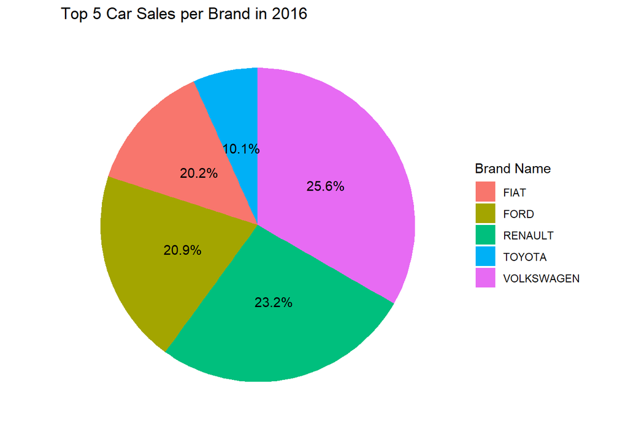

```r
raw_data1 =
    raw_data %>%
    filter(auto_total > 0 & comm_total > 0) %>%
    select(brand_name,auto_total,comm_total,total_total,year) %>%
    arrange(desc(year),desc(total_total)) %>%
    filter(brand_name != "TOPLAM:") %>%
    filter(brand_name != "ODD*") %>%
    filter(year == "2016") %>%
    group_by(brand_name) %>%
    summarize(year_total = sum(total_total)) %>%
    arrange(desc(year_total))

raw_data1 %>% top_n(5) %>%
    mutate(prop=percent(year_total / sum(year_total))) %>%
    ggplot(data = ., aes(x="", y=prop, fill=brand_name))+ labs(x = "", y = "", title = "Top 5 Car Sales per Brand in 2016") +
    geom_bar(width = 1, stat = "identity") + coord_polar("y", start=0) +
    theme(plot.title=element_text(hjust=0.5,face='bold',size=16)) +
    theme_classic() + theme(axis.line = element_blank(), axis.text = element_blank(), axis.ticks = element_blank()) +
    geom_text(aes(label=prop),position=position_stack(vjust = 0.5)) + guides(fill=guide_legend(title="Brand Name"))
```

### Analysis II

Secondly and lastly, I want to compare total annual automobile sales of FIAT and TOYOTA:

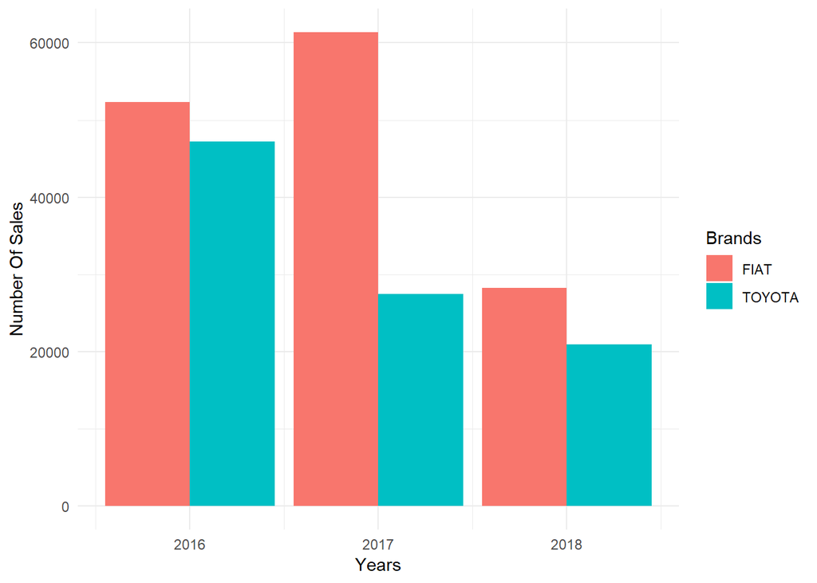

```r
#Total Annual Automobile Sales of FIAT and TOYOTA
raw_data %>%
  group_by(brand_name, year) %>%
  filter(brand_name %in% c("FIAT", "TOYOTA")) %>%
  summarize(yearly_auto_total = sum(auto_total))%>%
  ggplot(data=., aes(x=year, y=yearly_auto_total, fill=brand_name)) +
  geom_bar(stat="identity", position=position_dodge())+
  labs(x="Years", y = "Number Of Sales", fill="Brands") +
  theme_minimal()
```